# Sales Performance Analysis of Amazon E-Commerce Data in India from April to June 2022

## Sales Performance Analysis of Amazon E-Commerce Data in India from April to June 2022

Project by:  
**GLADYS LACIA**  
**Freelancer**, Professional Website at [GitHub: freelancergladyslacia.github.io](https://freelancergladyslacia.github.io/)  
**CONTENT WRITER | GENERAL VIRTUAL ASSISTANT | DATA ANALYST**  
onbizgladyslacia@gmail.com | [linkedin.com/in/freelancergladyslacia](https://www.linkedin.com/in/freelancergladyslacia/) | facebook.com/onbizgladyslacia  
[Upwork](https://www.upwork.com/freelancers/~01496f55ce7a5e12b1) | [OLJ](https://www.onlinejobs.ph/jobseekers/info/3977015)  
*Resume for Data Analyst role:* freelancergladyslacia.github.io/niche/data-analyst

### Rationale

This project aims to perform an in-depth Exploratory Data Analysis (EDA) and visualization of Amazon e-commerce sales report in India, from March 31, 2022, to June 29, 2022. Using Python libraries such as Pandas, NumPy, and Matplotlib, and through data wrangling and cleaning, it explores five main sales performance metrics:

1. Tracking total sales amount over time by applying Time Series Analysis, Descriptive Statistics, Rolling Mean/Moving Average, Coefficient of Variation (CV), Trend Identification, Seasonal Decomposition, and Outlier Detection.
2. Identifying top-selling product categories (with Sets and Kurtas leading in revenue) using Data Aggregation, Sorting, and Correlation Analysis.
3. Highlighting top-performing SKUs to focus marketing efforts through Data Aggregation, Sorting, and Filtering.
4. Examining sales channel performance (with Amazon.in accounting for 100% of sales) through Data Preprocessing, Aggregation, and Descriptive Statistics.
5. Uncovering weekly sales trends to optimize campaign timing by applying Time Series Analysis, Descriptive Statistics, Rolling Mean/Moving Average, Coefficient of Variation (CV), Trend Identification, Seasonal Decomposition, and Outlier Detection.

The analysis reveals consistent daily sales with moderate weekly fluctuations, strong alignment between sales volume and revenue growth, and the significant impact of top-performing products on overall sales and revenue. Based on these findings, the project recommends targeted strategies such as expanding top-performing categories, optimizing product listings, enhancing marketing initiatives, and diversifying sales channels. These actionable insights will support more efficient inventory management, smarter marketing investments, and data-driven decision-making within the highly competitive e-commerce industry.

```python
# Amazon Sales Report in India from April to June 2022. This is the initial DataFrame display.

import pandas as pd
from google.colab import data_table
from google.colab import drive

drive.mount('/content/drive')
file_path = '/content/drive/MyDrive/Portfolios/Data-Analyst/Gladys-Lacia-for-Data-Analyst-role/datasets/dataset-Amazon-Sales-Report-India-from-April-to-June-2022.csv'

df = pd.read_csv(file_path, low_memory=False)
df.info()
```

```
<class 'pandas.core.frame.DataFrame'>
RangeIndex: 128975 entries, 0 to 128974
Data columns (total 24 columns):
 #   Column              Non-Null Count   Dtype
---  ------              --------------   -----
 0   index               128975 non-null  int64
 1   Order ID            128975 non-null  object
 2   Date                128975 non-null  object
 3   Status              128975 non-null  object
 4   Fulfilment          128975 non-null  object
 5   Sales Channel       128975 non-null  object
 6   ship-service-level  128975 non-null  object
 7   Style               128975 non-null  object
 8   SKU                 128975 non-null  object
 9   Category            128975 non-null  object
```

[output cut: 16 more lines]

```python
# Data Cleaning and Preparation. This is handling missing values and removing unnecessary columns.

df['Courier Status'] = df.apply(lambda row: row['Status'] if pd.isna(row['Courier Status']) else row['Courier Status'], axis=1)
df.loc[df['Status'] == 'Shipped - Delivered to Buyer', 'Courier Status'] = 'Shipped'

df = df.dropna(subset=['Amount'])
df = df.drop(columns=['promotion-ids'])
df = df.drop(columns=['fulfilled-by'])
df = df.drop(columns=['Unnamed: 22'])
df.info()
```

```
<class 'pandas.core.frame.DataFrame'>
Index: 121180 entries, 0 to 128974
Data columns (total 21 columns):
 #   Column              Non-Null Count   Dtype
---  ------              --------------   -----
 0   index               121180 non-null  int64
 1   Order ID            121180 non-null  object
 2   Date                121180 non-null  object
 3   Status              121180 non-null  object
 4   Fulfilment          121180 non-null  object
 5   Sales Channel       121180 non-null  object
 6   ship-service-level  121180 non-null  object
 7   Style               121180 non-null  object
 8   SKU                 121180 non-null  object
 9   Category            121180 non-null  object
 10  Size                121180 non-null  object
 11  ASIN                121180 non-null  object
 12  Courier Status      121180 non-null  object
 13  Qty                 121180 non-null  int64
 14  currency            121180 non-null  object
 15  Amount              121180 non-null  float64
 16  ship-city           121149 non-null  object
 17  ship-state          121149 non-null  object
 18  ship-postal-code    121149 non-null  float64
 19  ship-country        121149 non-null  object
 20  B2B                 121180 non-null  bool
dtypes: bool(1), float64(2), int64(2), object(16)
memory usage: 19.5+ MB
```

## Analysis 1: Total Sales Amount Over Time

**Objective:** To track and understand if sales are increasing, decreasing, or fluctuating over the reporting period (March 31, 2022 to June 29, 2022), and why that might be happening.

**Question:** How did total sales amount change daily during the given period, and what patterns or anomalies can be observed?

### Recommendations

- Since sales are relatively consistent (CV = 18.13%), continue efforts that maintain operational stability such as inventory management, marketing consistency, and customer engagement programs.
- Investigate the causes behind noticeable peaks and dips such as promotions, external events, and supply chain issues.
- Capitalize on factors that drive peaks.
- Minimize the causes of dips.
- Optimize marketing and operations around the weekly cycle if weekends show higher sales, schedule promotions, advertising, and inventory replenishment accordingly.
- Introduce weekly offers or loyalty programs to reinforce peak buying behavior.
- To avoid significant deviations, investigate potential data quality issues such as missing or duplicate entries.
- Investigate unusual events such as supplier disruptions, payment failures, and system downtimes.

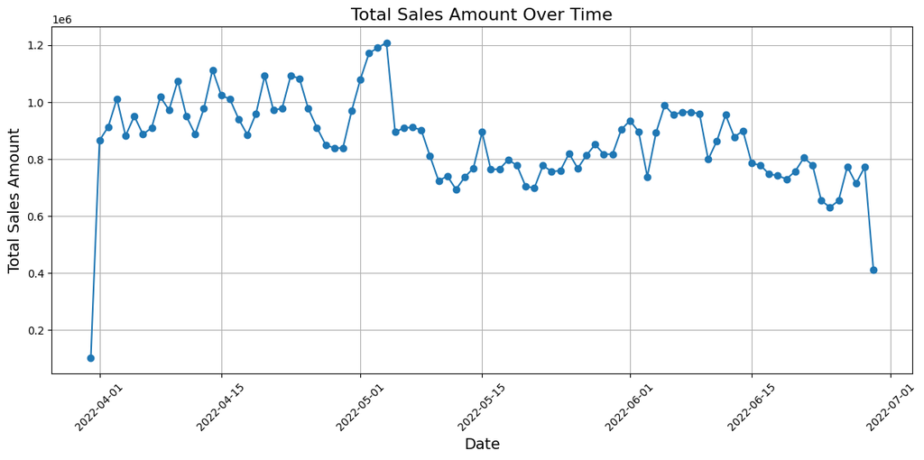

```python
# Time Series Visualization of Daily Sales Amounts

import matplotlib.pyplot as plt

df['Date'] = pd.to_datetime(df['Date'], format='%m-%d-%y')

sales_over_time = df.groupby('Date')['Amount'].sum().reset_index()

plt.figure(figsize=(12,6))
plt.plot(sales_over_time['Date'], sales_over_time['Amount'], marker='o', linestyle='-')
plt.title('Total Sales Amount Over Time', fontsize=16)
plt.xlabel('Date', fontsize=14)
plt.ylabel('Total Sales Amount', fontsize=14)
plt.grid(True)
plt.xticks(rotation=45)
plt.tight_layout()
plt.show()
```

```
There is no clear upward or downward trend in sales.
With 18.13% Coefficient of Variation (CV), sales are relatively consistent and stable.
```

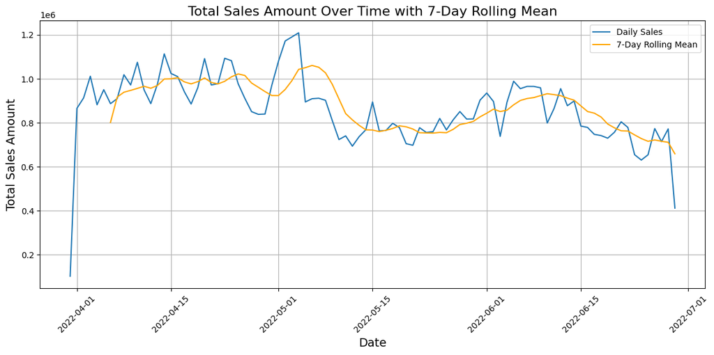

```python
# Insight Question: Is there a general upward or downward trend?
# Insight Question: Are sales relatively stable, or do they fluctuate significantly?

import numpy as np

sales_over_time['Rolling_Mean'] = sales_over_time['Amount'].rolling(window=7).mean()

if sales_over_time['Rolling_Mean'].iloc[-1] > sales_over_time['Rolling_Mean'].iloc[0]:
  trend = "an upward trend in sales."
elif sales_over_time['Rolling_Mean'].iloc[-1] < sales_over_time['Rolling_Mean'].iloc[0]:
  trend = "a downward trend in sales."
else:
  trend = "no clear upward or downward trend in sales."
print(f"There is {trend}")

cv = (sales_over_time['Amount'].std() / sales_over_time['Amount'].mean()) * 100
if cv <= 20:
    answer = "are relatively consistent and stable"
elif 20 < cv <= 50:
    answer = "are of moderate level of variation"
else:  # cv > 50
    answer = "variate and fluctuate significantly"

print(f"With {cv:.2f}% Coefficient of Variation (CV), sales {answer}.")

plt.figure(figsize=(12,6))
plt.plot(sales_over_time['Date'], sales_over_time['Amount'], label='Daily Sales')
plt.plot(sales_over_time['Date'], sales_over_time['Rolling_Mean'], label='7-Day Rolling Mean', color='orange')

# x = sales_over_time['Date'].map(lambda date: date.toordinal())
# y = sales_over_time['Amount']
# z = np.polyfit(x, y, 1)
# p = np.poly1d(z)
# plt.plot(sales_over_time['Date'], p(x), color='red', linestyle='--', linewidth=2, label='Trendline')

plt.title('Total Sales Amount Over Time with 7-Day Rolling Mean', fontsize=16)
plt.xlabel('Date', fontsize=14)
plt.ylabel('Total Sales Amount', fontsize=14)
plt.grid(True)
plt.xticks(rotation=45)
plt.legend()
plt.tight_layout()
plt.show()
```

```
5 Highest Peaks:
         Date      Amount  Rolling_Mean  Daily_Change
1  2022-04-01   865478.60           NaN     763794.75
65 2022-06-04   892476.10  8.571855e+05     154285.91
14 2022-04-14  1113487.56  9.990266e+05     136470.26
20 2022-04-20  1091926.41  1.003759e+06     131871.05
30 2022-04-30   969634.43  9.241895e+05     129979.78
5 Deepest Dips:
         Date     Amount  Rolling_Mean  Daily_Change
90 2022-06-29  411530.76  6.586663e+05    -360554.77
35 2022-05-05  894704.17  1.050902e+06    -314660.00
71 2022-06-10  798796.94  9.322649e+05    -160386.15
64 2022-06-03  738190.19  8.512585e+05    -158482.63
46 2022-05-16  763146.91  7.600047e+05    -131498.76
```

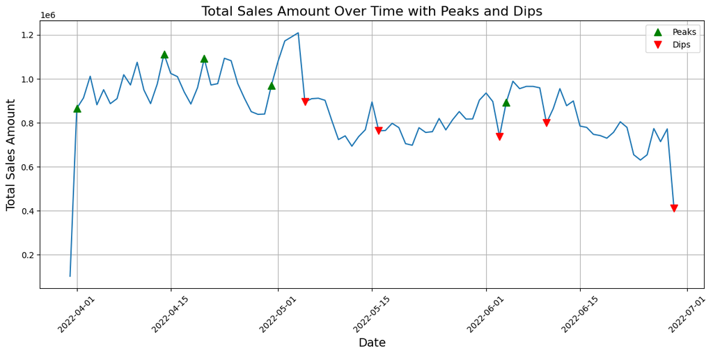

```python
# Insight Question: Are there any noticeable peaks or dips in sales during the period?
sales_over_time['Daily_Change'] = sales_over_time['Amount'].diff()

peaks = sales_over_time.nlargest(5, 'Daily_Change')
dips = sales_over_time.nsmallest(5, 'Daily_Change')

print("5 Highest Peaks:")
print(peaks)

print("5 Deepest Dips:")
print(dips)

plt.figure(figsize=(12, 6))
plt.plot(sales_over_time['Date'], sales_over_time['Amount'], linestyle='-')

plt.plot(peaks['Date'], peaks['Amount'], marker='^', markersize=8, color='green', linestyle='None', label='Peaks')
plt.plot(dips['Date'], dips['Amount'], marker='v', markersize=8, color='red', linestyle='None', label='Dips')

plt.title('Total Sales Amount Over Time with Peaks and Dips', fontsize=16)
plt.xlabel('Date', fontsize=14)
plt.ylabel('Total Sales Amount', fontsize=14)
plt.grid(True)
plt.xticks(rotation=45)
plt.legend()
plt.tight_layout()
plt.show()
```

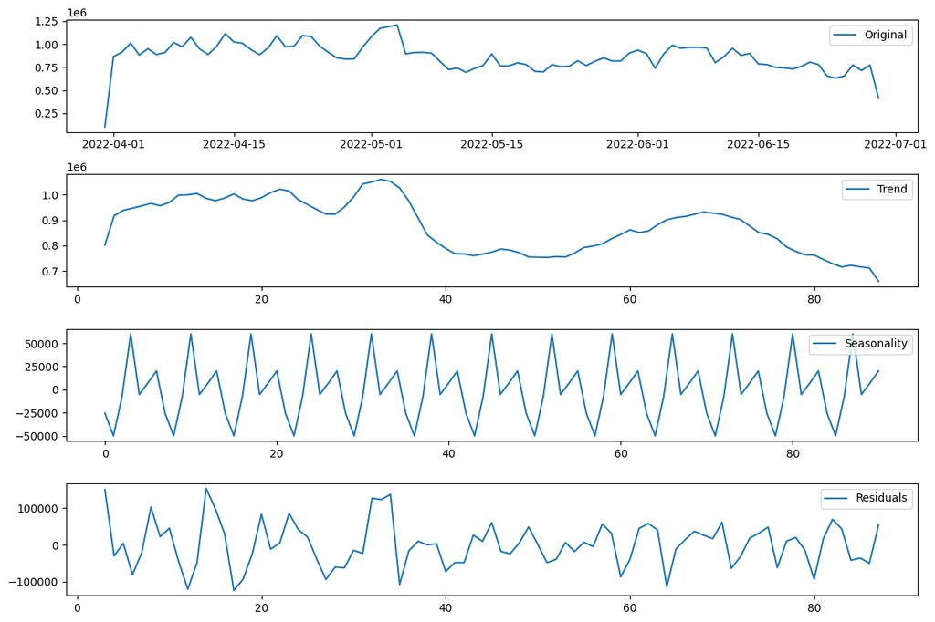

```
Average Weekly Seasonality:
 0   -25407.377584
1   -49824.359012
2    -7171.516155
3    60141.991574
4    -5172.940322
5     7228.223964
6    20205.977535
Name: seasonal, dtype: float64
```

```python
# Insight Question: Are there recurring patterns or cycles in sales, such as weekly trends?

from statsmodels.tsa.seasonal import seasonal_decompose
decomposition = seasonal_decompose(sales_over_time['Amount'], model='additive', period=7)
plt.figure(figsize=(12, 8))

plt.subplot(411)
plt.plot(sales_over_time['Date'], sales_over_time['Amount'], label='Original')
plt.legend(loc='best')
plt.subplot(412)
plt.plot(decomposition.trend, label='Trend')
plt.legend(loc='best')
plt.subplot(413)
plt.plot(decomposition.seasonal, label='Seasonality')
plt.legend(loc='best')
plt.subplot(414)
plt.plot(decomposition.resid, label='Residuals')
plt.legend(loc='best')

plt.tight_layout()
plt.show()

weekly_seasonality = decomposition.seasonal.groupby(sales_over_time.index % 7).mean()
print("Average Weekly Seasonality:\n", weekly_seasonality)
```

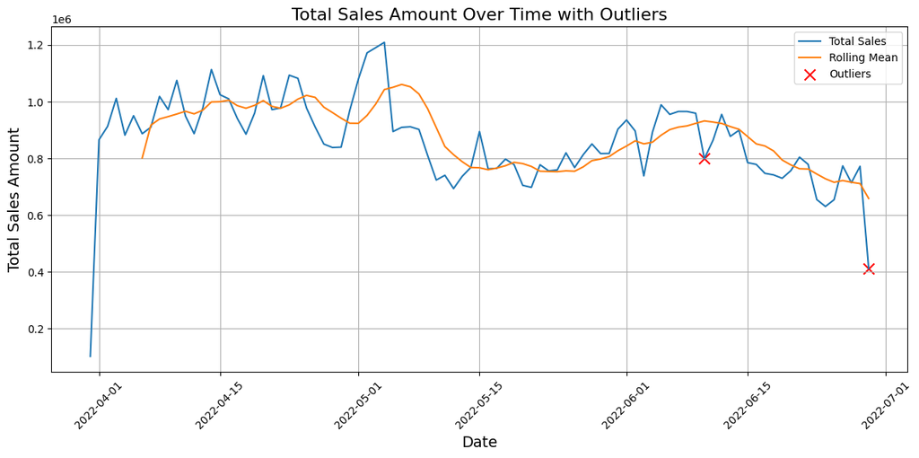

```python
# Insight Question: Are there any data points that significantly deviate from the general trend?

sales_over_time['rolling_mean'] = sales_over_time['Amount'].rolling(window=7).mean()  # 7-day rolling mean
sales_over_time['rolling_std'] = sales_over_time['Amount'].rolling(window=7).std()

sales_over_time['deviation'] = abs(sales_over_time['Amount'] - sales_over_time['rolling_mean']) / sales_over_time['rolling_std']
outliers = sales_over_time[sales_over_time['deviation'] > 2]

if len(outliers) > 0:
  plt.figure(figsize=(12, 6))
  plt.plot(sales_over_time['Date'], sales_over_time['Amount'], label='Total Sales')
  plt.plot(sales_over_time['Date'], sales_over_time['rolling_mean'], label='Rolling Mean')
  plt.scatter(outliers['Date'], outliers['Amount'], color='red', marker='x', s=100, label='Outliers')
  plt.title('Total Sales Amount Over Time with Outliers', fontsize=16)
  plt.xlabel('Date', fontsize=14)
  plt.ylabel('Total Sales Amount', fontsize=14)
  plt.grid(True)
  plt.xticks(rotation=45)
  plt.legend()
  plt.tight_layout()
  plt.show()
else:
  print("There are NO data points that significantly deviate from the general trend.")
```

## Analysis 2: Top-Selling Categories

**Objective:** To identify the most profitable and most popular product categories, so that the company can focus more resources on them, and maybe optimize or rethink underperforming ones.

**Question:** Which product categories generated the highest total sales (by amount and quantity) during the given period, and how do they compare?

### Recommendations

- Expand product offerings within the Set and Kurta categories (more styles, colors, or sizes) to capture more market share.
- Run targeted promotions or bundles specifically for Sets and Kurtas to maximize their contribution.
- Invest in strategies that boost sales volume such as discounts on bulk purchases, loyalty programs rewarding frequent buyers, flash sales and limited-time offers to encourage faster purchases, and collaborations with influencers to drive traffic and volume.
- Ensure sufficient stock availability for Sets and Kurtas to avoid stockouts, especially during peak sales periods.
- Bundle Sets and Kurtas with other items (Western Dress, Top, Ethnic Dress, Blouse, Bottom, Saree, Dupatta) to increase average order value while further boosting sales volume.
- Allocate more advertising budget to promote Sets and Kurtas on high-performing sales channels.

```
        Category  Total_Quantity  Total_Sales_Amount
5            Set           45225         39204124.03
8          kurta           44970         21299546.70
7  Western Dress           13939         11216072.69
6            Top            9899          5347792.30
3   Ethnic Dress            1053           791217.66
0         Blouse             844           458408.18
1         Bottom             397           150667.98
4          Saree             152           123933.76
2        Dupatta               3              915.00
```

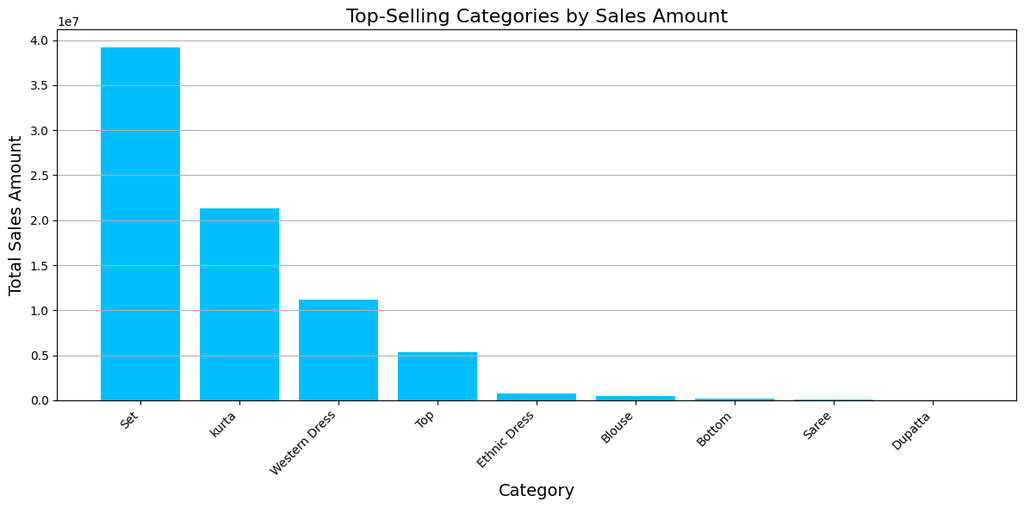

```python
# Category Sales Analysis and Visualization

category_sales = df.groupby('Category').agg(
    Total_Quantity=('Qty', 'sum'),
    Total_Sales_Amount=('Amount', 'sum')
).reset_index()

category_sales = category_sales.sort_values(by='Total_Sales_Amount', ascending=False)
print(category_sales)

plt.figure(figsize=(12,6))
plt.bar(category_sales['Category'], category_sales['Total_Sales_Amount'], color='deepskyblue')
plt.title('Top-Selling Categories by Sales Amount', fontsize=16)
plt.xlabel('Category', fontsize=14)
plt.ylabel('Total Sales Amount', fontsize=14)
plt.xticks(rotation=45, ha='right')
plt.grid(axis='y')
plt.tight_layout()
plt.show()
```

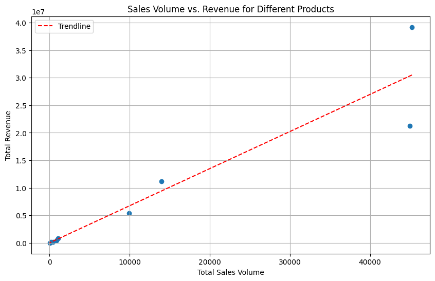

```
Correlation between sales volume and revenue: 0.9427397212017551
```

```python
# Insight:  The relationship between sales volume and revenue for different products.

product_sales = df.groupby('Category').agg(
    Total_Sales_Volume=('Qty', 'sum'),
    Total_Revenue=('Amount', 'sum')
).reset_index()
product_sales = product_sales.sort_values('Total_Revenue', ascending=False)

plt.figure(figsize=(10, 6))
plt.scatter(product_sales['Total_Sales_Volume'], product_sales['Total_Revenue'])
plt.title('Sales Volume vs. Revenue for Different Products')
plt.xlabel('Total Sales Volume')
plt.ylabel('Total Revenue')
plt.grid(True)

z = np.polyfit(product_sales['Total_Sales_Volume'], product_sales['Total_Revenue'], 1)  # 1 = linear
p = np.poly1d(z)
plt.plot(product_sales['Total_Sales_Volume'], p(product_sales['Total_Sales_Volume']), color='red', linestyle='--', label='Trendline')
plt.legend()
plt.show()

correlation = product_sales['Total_Sales_Volume'].corr(product_sales['Total_Revenue'])
print(f"Correlation between sales volume and revenue: {correlation}")
```

## Analysis 3: Top Products (SKU or Style) by Sales

**Objective:** To find out which specific products are driving the most revenue and sales volume, so that the company can double down on bestsellers and optimize inventory, marketing, and pricing strategies.

**Question:** Which individual products (identified by SKU or Style) generated the highest total sales revenue and/or quantity sold during the given period (March 31, 2022 to June 29, 2022)?

### Insights

- J0230-SKD-M generated the highest revenue during April-June 2022.

### Recommendations

- Prioritize marketing and promotional efforts towards the top 10 SKUs to further capitalize on their popularity and drive even more sales.

```
                 SKU  Total_Quantity  Total_Sales_Amount
1333     J0230-SKD-M             468           527699.20
4518    JNE3797-KR-L             661           524581.77
1334     J0230-SKD-S             421           479937.14
4519    JNE3797-KR-M             561           454290.16
4520    JNE3797-KR-S             503           407302.57
...              ...             ...                 ...
6478  SET306-KR-PP-S               1                0.00
261      BTM041-PP-L               2                0.00
3107  JNE3486-KR-XXL               1                0.00
4200    JNE3748-KR-S               1                0.00
457    J0027-SET-XXL               1                0.00

[7157 rows x 3 columns]
```

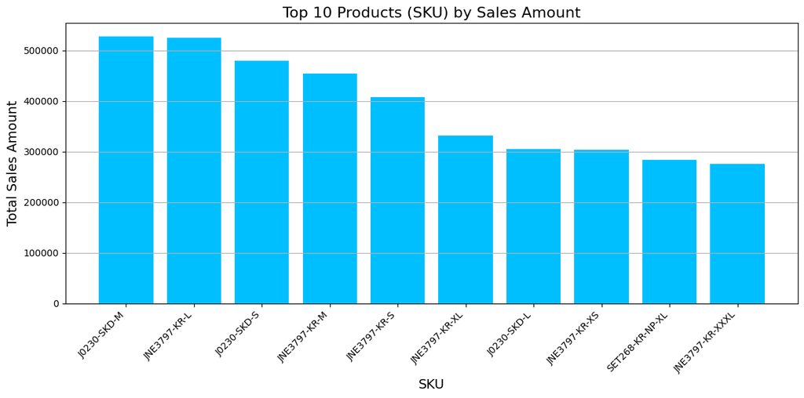

```python
# Top-Selling Products Analysis

sku_sales = df.groupby('SKU').agg(
    Total_Quantity=('Qty', 'sum'),
    Total_Sales_Amount=('Amount', 'sum')
).reset_index()
sku_sales = sku_sales.sort_values(by='Total_Sales_Amount', ascending=False)
print(sku_sales)

top10_skus = sku_sales.head(10)

plt.figure(figsize=(12,6))
plt.bar(top10_skus['SKU'], top10_skus['Total_Sales_Amount'], color='deepskyblue')
plt.title('Top 10 Products (SKU) by Sales Amount', fontsize=16)
plt.xlabel('SKU', fontsize=14)
plt.ylabel('Total Sales Amount', fontsize=14)
plt.xticks(rotation=45, ha='right')
plt.grid(axis='y')
plt.tight_layout()
plt.show()
```

```
                     SKU  Total_Quantity  Total_Sales_Amount
4518        JNE3797-KR-L             661           524581.77
4519        JNE3797-KR-M             561           454290.16
4520        JNE3797-KR-S             503           407302.57
2722        JNE3405-KR-L             480           194645.29
1333         J0230-SKD-M             468           527699.20
...                  ...             ...                 ...
2787      JNE3423-KR-A-S               0              414.29
6096      SET235-KR-PP-S               0              498.10
6163  SET247-KR-SHA-XXXL               0              647.62
28          AN210-NAVY-M               0              286.67
10       AN204-PURPLE-XL               0              306.67

[7157 rows x 3 columns]
```

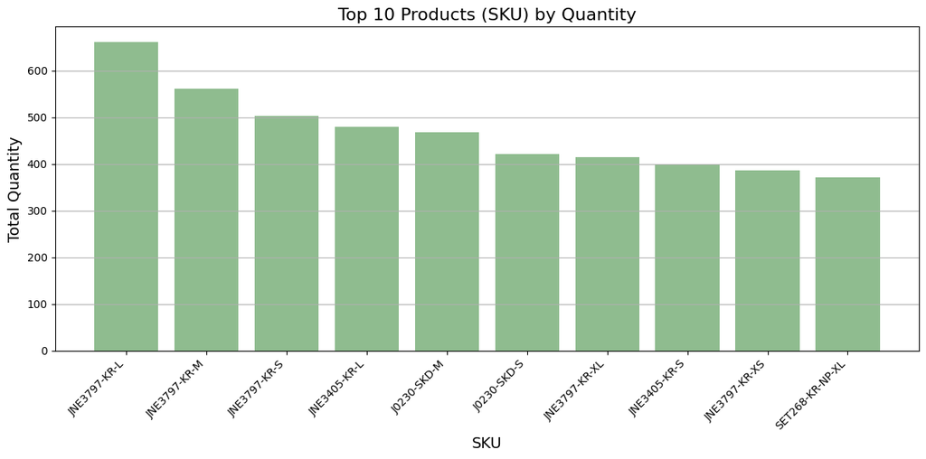

```python
# Top 10 Products (SKU) by Quantity

sku_sales = df.groupby('SKU').agg(
    Total_Quantity=('Qty', 'sum'),
    Total_Sales_Amount=('Amount', 'sum')
).reset_index()
sku_sales = sku_sales.sort_values(by='Total_Quantity', ascending=False)
print(sku_sales)

top10_skus = sku_sales.head(10)

plt.figure(figsize=(12,6))
plt.bar(top10_skus['SKU'], top10_skus['Total_Quantity'], color='darkseagreen')
plt.title('Top 10 Products (SKU) by Quantity', fontsize=16)
plt.xlabel('SKU', fontsize=14)
plt.ylabel('Total Quantity', fontsize=14)
plt.xticks(rotation=45, ha='right')
plt.grid(axis='y')
plt.tight_layout()
plt.show()
```

## Analysis 4: Sales Channel Comparison

**Objective:** To identify which sales channels (e.g., online, retail, wholesale) are contributing the most revenue and whether some channels are underperforming or overperforming relative to others.

**Question:** Which sales channels are driving the most revenue, and how do these channels compare in terms of total sales performance?

### Insights

- Amazon.in made up to 100% of the total sales amount.

### Recommendations

- Optimize the online store presence in Amazon.in by:
- Improving product listings (SEO-optimized titles, bullet points, descriptions).
- Using high-quality images and videos.
- Gathering positive customer reviews and ratings.
- Running Amazon Sponsored Ads to maintain and grow visibility.
- Explore other marketplaces like Shopee, Lazada, Shein, and Temu websites to reduce reliance on a single platform.
- Launching a brand-owned e-commerce site could help build a loyal customer base and retain more margin.
- Since depending on a single channel is risky (account suspension or policy changes), develop a contingency plan such as:
- Having a backup sales platform ready.
- Building an email list or social media presence to drive traffic independently.
- Take advantage of Amazon-specific programs like Amazon Prime listings, Amazon Lightning Deals, and Deal of the Day.

```
Index(['index', 'Order ID', 'Date', 'Status', 'Fulfilment', 'Sales Channel',
       'ship-service-level', 'Style', 'SKU', 'Category', 'Size', 'ASIN',
       'Courier Status', 'Qty', 'currency', 'Amount', 'ship-city',
       'ship-state', 'ship-postal-code', 'ship-country', 'B2B'],
      dtype='object')
Missing values in 'Sales Channel': 0
Missing values in 'Amount': 0
  Sales Channel  Total_Sales_Amount
0     Amazon.in          78592678.3
```

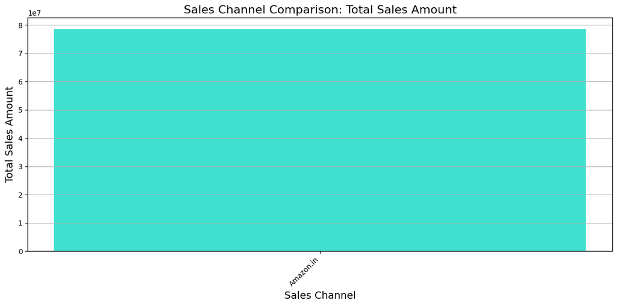

```python
# Sales Channel Performance

df.columns = df.columns.str.strip()
print(df.columns)

if 'Sales Channel' not in df.columns:
    print("The 'Sales Channel' column is missing or has a different name.")
else:
    print(f"Missing values in 'Sales Channel': {df['Sales Channel'].isna().sum()}")
    print(f"Missing values in 'Amount': {df['Amount'].isna().sum()}")

    df = df.dropna(subset=['Sales Channel', 'Amount'])
    df['Amount'] = pd.to_numeric(df['Amount'], errors='coerce')

    sales_channel_comparison = df.groupby('Sales Channel').agg(
        Total_Sales_Amount=('Amount', 'sum')
    ).reset_index()
    sales_channel_comparison = sales_channel_comparison.sort_values(by='Total_Sales_Amount', ascending=False)
    print(sales_channel_comparison)

    plt.figure(figsize=(12,6))
    plt.bar(sales_channel_comparison['Sales Channel'], sales_channel_comparison['Total_Sales_Amount'], color='turquoise')
    plt.title('Sales Channel Comparison: Total Sales Amount', fontsize=16)
    plt.xlabel('Sales Channel', fontsize=14)
    plt.ylabel('Total Sales Amount', fontsize=14)
    plt.xticks(rotation=45, ha='right')
    plt.grid(axis='y')
    plt.tight_layout()
    plt.show()
```

## Analysis 5: Weekly Sales Trends

**Objective:** To track daily changes in sales to spot trends (e.g., spikes or drops) and understand the pattern of sales across different weeks.

**Question:** How does the total sales amount fluctuate on a weekly basis, and what are the underlying trends or patterns in sales over time?

### Recommendations

- Since weekly sales show a moderate variation (CV = 27.46%), implement strategies to smooth fluctuations, such as consistent weekly promotions, regular marketing activities, and loyalty programs that encourage repeat purchases every week.
- If certain days consistently perform better, schedule product launches or promotions around them.
- Offer special deals or events tied to known peak days.
- Replicate successful activities during low-performing weeks to drive more consistent sales.
- Introduce "booster campaigns" during historically low-sales weeks to counteract drops.
- *Maintain Current Quality Controls:* Since there are no significant outliers, continue current data management, sales operations, and customer engagement practices that help maintain a steady pattern.

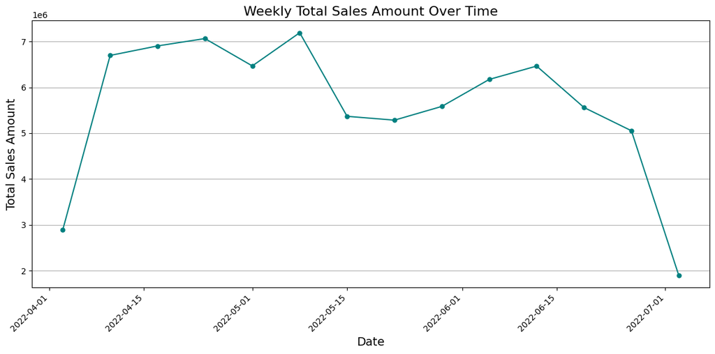

```python
# Weekly Sales Trend Analysis

df['Date'] = pd.to_datetime(df['Date'], errors='coerce')
df = df.dropna(subset=['Date'])

weekly_sales = df.resample('W', on='Date').agg(
    Total_Sales_Amount=('Amount', 'sum')
).reset_index()

plt.figure(figsize=(12,6))
plt.plot(weekly_sales['Date'], weekly_sales['Total_Sales_Amount'], marker='o', color='teal', linestyle='-', markersize=5)
plt.title('Weekly Total Sales Amount Over Time', fontsize=16)
plt.xlabel('Date', fontsize=14)
plt.ylabel('Total Sales Amount', fontsize=14)
plt.xticks(rotation=45, ha='right')
plt.grid(axis='y')
plt.tight_layout()
plt.show()
```

```
There is no clear upward or downward trend in weekly sales.
With 27.46% Coefficient of Variation (CV), weekly sales show a moderate level of variation.
```

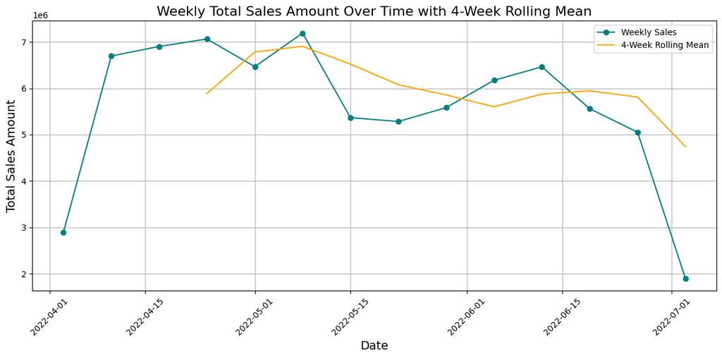

```python
import numpy as np

sales_over_time_weekly = sales_over_time.resample('W', on='Date').sum().reset_index()
sales_over_time_weekly['Rolling_Mean'] = sales_over_time_weekly['Amount'].rolling(window=4).mean()

if sales_over_time_weekly['Rolling_Mean'].iloc[-1] > sales_over_time_weekly['Rolling_Mean'].iloc[0]:
    trend = "an upward trend in weekly sales."
elif sales_over_time_weekly['Rolling_Mean'].iloc[-1] < sales_over_time_weekly['Rolling_Mean'].iloc[0]:
    trend = "a downward trend in weekly sales."
else:
    trend = "no clear upward or downward trend in weekly sales."
print(f"There is {trend}")

cv = (sales_over_time_weekly['Amount'].std() / sales_over_time_weekly['Amount'].mean()) * 100
if cv <= 20:
    answer = "are relatively consistent and stable"
elif 20 < cv <= 50:
    answer = "show a moderate level of variation"
else:
    answer = "fluctuate significantly"
print(f"With {cv:.2f}% Coefficient of Variation (CV), weekly sales {answer}.")

plt.figure(figsize=(12,6))
plt.plot(sales_over_time_weekly['Date'], sales_over_time_weekly['Amount'], label='Weekly Sales', marker='o', color='teal')
plt.plot(sales_over_time_weekly['Date'], sales_over_time_weekly['Rolling_Mean'], label='4-Week Rolling Mean', color='orange')

# x = sales_over_time_weekly['Date'].map(lambda date: date.toordinal())
# y = sales_over_time_weekly['Amount']
# z = np.polyfit(x, y, 1)
# p = np.poly1d(z)
# plt.plot(sales_over_time_weekly['Date'], p(x), color='red', linestyle='--', label='Trendline')

plt.title('Weekly Total Sales Amount Over Time with 4-Week Rolling Mean', fontsize=16)
plt.xlabel('Date', fontsize=14)
plt.ylabel('Total Sales Amount', fontsize=14)
plt.grid(True)
plt.xticks(rotation=45)
plt.legend()
plt.tight_layout()
plt.show()
```

```
5 Highest Weekly Peaks:
         Date      Amount  Rolling_Mean  Daily_Change  rolling_mean  \
1  2022-04-10  6695415.95  4.561683e+06      63470.65  4.561683e+06
5  2022-05-08  7190464.94  7.177691e+06    -177784.46  7.177691e+06
9  2022-06-05  6172395.21  5.929235e+06     172096.54  5.929235e+06
8  2022-05-29  5583804.55  5.377584e+06      39443.66  5.377584e+06
10 2022-06-12  6463328.67  6.433892e+06     -33846.21  6.433892e+06

     rolling_std  deviation  Weekly_Change
1   5.473129e+05   3.918140     3803388.59
5   1.032151e+06   7.938578      723664.98
9   3.983719e+05   7.979455      588590.66
8   2.743525e+05   5.230721      299919.22
10  5.380610e+05   5.764973      290933.46

5 Deepest Weekly Dips:
         Date      Amount  Rolling_Mean  Daily_Change  rolling_mean  \
13 2022-07-03  1897740.96  2.085592e+06    -362079.26  2.085592e+06
6  2022-05-15  5367831.55  5.862578e+06      -7527.39  5.862578e+06
11 2022-06-19  5559803.37  6.007860e+06    -225406.22  6.007860e+06
4  2022-05-01  6466799.96  6.769772e+06      -2526.43  6.769772e+06
12 2022-06-26  5053074.03  5.213443e+06      43769.42  5.213443e+06

      rolling_std  deviation  Weekly_Change
13  258686.815694   2.970255    -3155333.07
6   710419.936879   7.254924    -1822633.39
11  488868.520205   6.265102     -903525.30
4   618467.455637   7.979073     -596606.04
12  362134.260252   7.574513     -506729.34
```

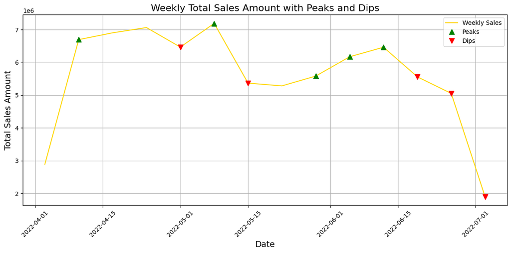

```python
sales_over_time_weekly = sales_over_time.resample('W', on='Date').sum().reset_index()
sales_over_time_weekly['Weekly_Change'] = sales_over_time_weekly['Amount'].diff()

peaks = sales_over_time_weekly.nlargest(5, 'Weekly_Change')
dips = sales_over_time_weekly.nsmallest(5, 'Weekly_Change')

print("5 Highest Weekly Peaks:")
print(peaks)

print("\n5 Deepest Weekly Dips:")
print(dips)

plt.figure(figsize=(12, 6))
plt.plot(sales_over_time_weekly['Date'], sales_over_time_weekly['Amount'], linestyle='-', color='gold', label='Weekly Sales')

plt.plot(peaks['Date'], peaks['Amount'], marker='^', markersize=8, color='green', linestyle='None', label='Peaks')
plt.plot(dips['Date'], dips['Amount'], marker='v', markersize=8, color='red', linestyle='None', label='Dips')

plt.title('Weekly Total Sales Amount with Peaks and Dips', fontsize=16)
plt.xlabel('Date', fontsize=14)
plt.ylabel('Total Sales Amount', fontsize=14)
plt.grid(True)
plt.xticks(rotation=45)
plt.legend()
plt.tight_layout()
plt.show()
```

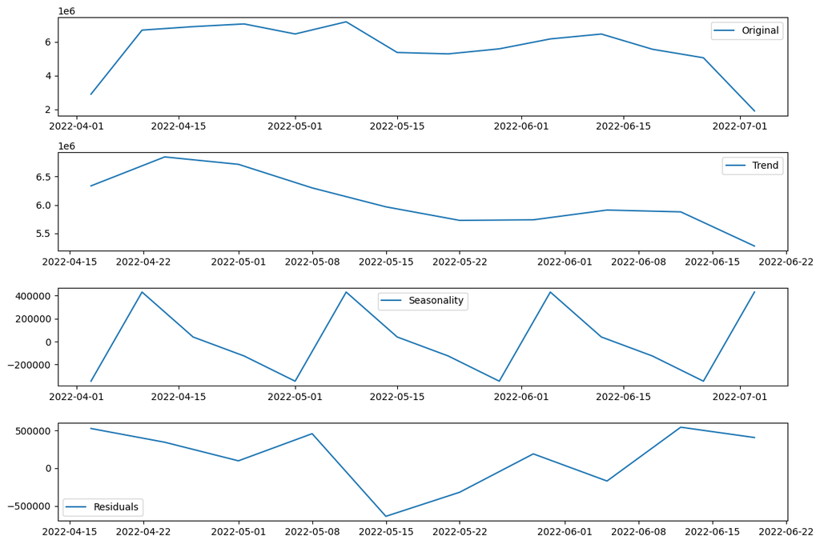

```python
from statsmodels.tsa.seasonal import seasonal_decompose

sales_over_time_weekly = sales_over_time.resample('W', on='Date').sum().reset_index()
sales_over_time_weekly.set_index('Date', inplace=True)

decomposition = seasonal_decompose(sales_over_time_weekly['Amount'], model='additive', period=4)
plt.figure(figsize=(12, 8))

plt.subplot(411)
plt.plot(sales_over_time_weekly.index, sales_over_time_weekly['Amount'], label='Original')
plt.legend(loc='best')

plt.subplot(412)
plt.plot(decomposition.trend, label='Trend')
plt.legend(loc='best')

plt.subplot(413)
plt.plot(decomposition.seasonal, label='Seasonality')
plt.legend(loc='best')

plt.subplot(414)
plt.plot(decomposition.resid, label='Residuals')
plt.legend(loc='best')

plt.tight_layout()
plt.show()

# weekly_seasonality = decomposition.seasonal.groupby(decomposition.seasonal.index.isocalendar().week).mean()
# print("Average Weekly Seasonality:\n", weekly_seasonality)
```

```python
sales_over_time_weekly = sales_over_time.resample('W', on='Date').sum().reset_index()

sales_over_time_weekly['rolling_mean'] = sales_over_time_weekly['Amount'].rolling(window=4).mean()
sales_over_time_weekly['rolling_std'] = sales_over_time_weekly['Amount'].rolling(window=4).std()

sales_over_time_weekly['deviation'] = abs(sales_over_time_weekly['Amount'] - sales_over_time_weekly['rolling_mean']) / sales_over_time_weekly['rolling_std']
outliers = sales_over_time_weekly[sales_over_time_weekly['deviation'] > 2]

if len(outliers) > 0:
    plt.figure(figsize=(12, 6))
    plt.plot(sales_over_time_weekly['Date'], sales_over_time_weekly['Amount'], label='Weekly Sales', color='teal')
    plt.plot(sales_over_time_weekly['Date'], sales_over_time_weekly['rolling_mean'], label='4-Week Rolling Mean', color='orange')
    plt.scatter(outliers['Date'], outliers['Amount'], color='red', marker='x', s=100, label='Outliers')
    plt.title('Weekly Total Sales Amount Over Time with Outliers', fontsize=16)
    plt.xlabel('Date', fontsize=14)
    plt.ylabel('Total Sales Amount', fontsize=14)
    plt.grid(True)
    plt.xticks(rotation=45)
    plt.legend()
    plt.tight_layout()
    plt.show()
else:
    print("There are NO weekly data points that significantly deviate from the general trend.")
```

```
There are NO weekly data points that significantly deviate from the general trend.
```

Professional Website at [GitHub: freelancergladyslacia.github.io](https://freelancergladyslacia.github.io/)  
Contact at onbizgladyslacia@gmail.com | [linkedin.com/in/freelancergladyslacia](https://www.linkedin.com/in/freelancergladyslacia/) | facebook.com/onbizgladyslacia  
Project created in September 2024